# Lab 18: Inference for the Mean

## Instructions

Below you will find several empty R code scripts and answer prompts. Your task is to fill in the required code snippets and answer the corresponding questions.

## Teacher Salary

The available variables are

- base: Base annual salary, in dollars
- degree: Highest educational degree attained: BA (Bachelor’s) or MA (Master’s)
- years: Number of years employeed

Using the mean function, what is the average base pay of all teachers in the dataset?

```
## [1] 56937.61
```

Fit a model for the mean of the base pay variable using lm_basic. Save the model as an object called “model”:

Using a call to `reg_table`, find the mean implied by the model:

```
##
## Call:
## lm_basic(formula = base ~ 1, data = teachers)
##
## Residuals:
##    Min     1Q Median     3Q    Max
## -21511  -5764   2976   8422  11292
##
## Coefficients:
##             Estimate
## (Intercept)    56938
##
## Residual standard error: 9029 on 69 degrees of freedom
```

Does the mean agree with your answer to question 2?

**Answer**: The numbers aren’t exactly the same; from question 2 it was 56937.61, and this mean is 56938, but they are close enough to where I would say they do agree.

Add a 95% confidence interval to the regression table.

```
##
## Call:
## lm_basic(formula = base ~ 1, data = teachers)
##
## Residuals:
##    Min     1Q Median     3Q    Max
## -21511  -5764   2976   8422  11292
##
## Coefficients:
##             Estimate 2.5 % 97.5 %
## (Intercept)    56938 54785  59091
##
## Residual standard error: 9029 on 69 degrees of freedom
```

What is the range of mean salaries implied by the confidence interval?

**Answer**: The range of mean salaries could be fromn 54,785 to 59,091 dollars.

Draw a histogram of the base salary values for the entire dataset.

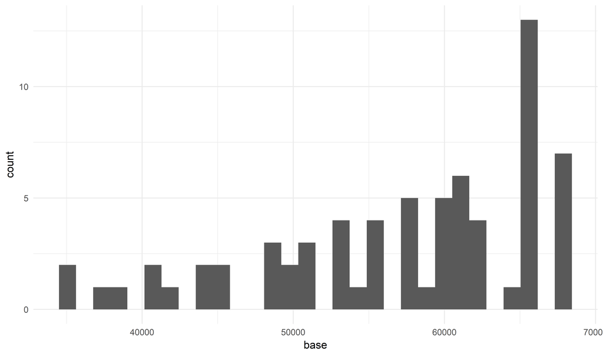

Do most of the salary values fall within the range given in question 5? Why or why not?

**Answer**: Most of the salary values fall outside of the range specified. The confidence interval is used to guess at the mean, not explain the data as a whole.

Use the filter command to construct a new dataset called `masters` consisting of just those teachers with a masters degree.

```
## # A tibble: 31 x 3
##     base degree years
##    <int> <chr>  <dbl>
##  1 60649 MA     15.0
##  2 60649 MA     16.0
##  3 68230 MA     32.0
##  4 51174 MA      7.00
##  5 68230 MA     36.0
##  6 64440 MA     20.0
##  7 68230 MA     28.5
##  8 51174 MA      8.00
##  9 45486 MA      4.00
## 10 54962 MA      9.00
## # ... with 21 more rows
```

Compute a 95% confidence interval for the mean pay of teachers with a master’s degree. Does this range intersect the one you had in question 5?

```
##
## Call:
## lm_basic(formula = base ~ 1, data = masters)
##
## Residuals:
##      Min       1Q   Median       3Q      Max
## -16098.7  -5673.2    958.3   5698.8  10436.3
##
## Coefficients:
##             Estimate 2.5 % 97.5 %
## (Intercept)    57794 54891  60697
##
## Residual standard error: 7915 on 30 degrees of freedom
```

## Murder Data

Now load the following dataset containing all murders that have occurred in London from 1 January 2006 to 7 September 7 2011.

The available variables are:

- age: age of the victim in years
- year: year of the murder
- borough: the London borough in which the murder took place

Find an 80% confidence interval for the average age of the victim of a murder in London.

```
##
## Call:
## lm_basic(formula = age ~ 1, data = london)
##
## Residuals:
##     Min      1Q  Median      3Q     Max
## -32.858 -12.858  -3.858  10.142  66.142
##
## Coefficients:
##             Estimate  10 %  90 %
## (Intercept)    33.86 33.07 34.65
##
## Residual standard error: 17.85 on 837 degrees of freedom
```

Make sure you actually extract the answer here:

**Answer**: The average age of murder victims in London is 33.86, so roughly 34 years old.

Describe in words how the proceeding confidence interval should be interpreted.

**Answer**: The confidence interval suggests that although the best guess of the average age of murder victims in London is 33.86, the mean age could very well fall anywhere between the ages of 33.07 and 34.65.